# 12-GARCH

Choose a time series from Nikkei stock market data and apply GARCH(1,1). Compare the test set with the forecast and comment on the deviations in forecast. Also, make comparison with the ARIMA forecast obtained in Ex-11.

```python
import numpy as np
import matplotlib.pyplot as plt
import pandas as pd
import seaborn as sns
# !pip install pmdarima
import pmdarima
```

```python
# We open the data and make the ticker as the index
df = pd.read_csv('Nikkei-2010-2012.csv',index_col="Ticker")
df.head()
```

| Ticker | 2010-01-04 | 2010-01-05 | 2010-01-06 | 2010-01-07 | 2010-01-08 | 2010-01-12 | 2010-01-13 | 2010-01-14 | 2010-01-15 | 2010-01-18 | ... | 2012-12-14 | 2012-12-17 | 2012-12-18 | 2012-12-19 | 2012-12-20 | 2012-12-21 | 2012-12-25 | 2012-12-26 | 2012-12-27 | 2012-12-28 |
| --- | --- | --- | --- | --- | --- | --- | --- | --- | --- | --- | --- | --- | --- | --- | --- | --- | --- | --- | --- | --- | --- |
| 4151.t | 999.0 | 989.0 | 1003.0 | 984.0 | 991.0 | 984.0 | 985.0 | 990.0 | 989.0 | 975.0 | ... | 845.0 | 848.0 | 852.0 | 861.0 | 850.0 | 852.0 | 856.0 | 850.0 | 851.0 | 849.0 |
| 4502.t | 3850.0 | 3870.0 | 3870.0 | 3930.0 | 3900.0 | 3940.0 | 3930.0 | 3970.0 | 3970.0 | 3945.0 | ... | 3805.0 | 3835.0 | 3845.0 | 3870.0 | 3875.0 | 3865.0 | 3865.0 | 3865.0 | 3860.0 | 3855.0 |
| 4503.t | 694.0 | 700.0 | 700.0 | 700.0 | 702.0 | 700.0 | 696.0 | 704.0 | 702.0 | 697.0 | ... | 797.0 | 800.0 | 809.0 | 812.0 | 802.0 | 792.0 | 797.0 | 798.0 | 780.0 | 775.0 |
| 4506.t | 979.0 | 984.0 | 991.0 | 982.0 | 981.0 | 977.0 | 979.0 | 982.0 | 980.0 | 965.0 | ... | 999.0 | 1013.0 | 1019.0 | 1026.0 | 1012.0 | 1010.0 | 1021.0 | 1032.0 | 1033.0 | 1035.0 |
| 4507.t | 2003.0 | 2007.0 | 2007.0 | 1957.0 | 1930.0 | 1931.0 | 1904.0 | 1968.0 | 1957.0 | 1926.0 | ... | 1349.0 | 1382.0 | 1443.0 | 1462.0 | 1461.0 | 1457.0 | 1454.0 | 1469.0 | 1479.0 | 1437.0 |

5 rows × 736 columns

We select one of the time series to which we will apply GARCH

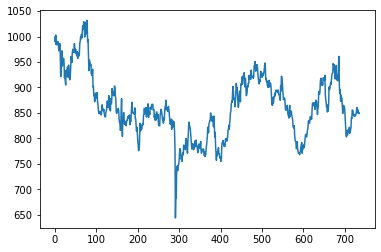

```python
series = df.iloc[0,:]
plt.plot(np.array(series))
```

Plot the 7 day rolling mean and rolling std

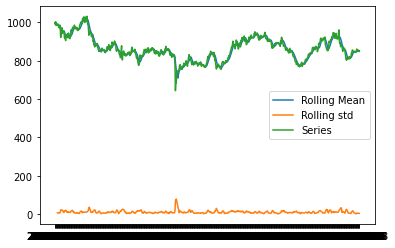

```python
plt.plot(series.rolling(7).mean(),label="Rolling Mean")
plt.plot(series.rolling(7).std(),label="Rolling std")
plt.plot(series,label="Series")
plt.legend()
```

We calculate the stationarity of the time series using the adfuller function

```python
import statsmodels.tsa.stattools as st
adf = st.adfuller(x=series, regression="ct", maxlag=12)
print("adf:", adf[0], "adf_pvalue:", adf[1])
```

```
adf: -3.160714505347424 adf_pvalue: 0.09251781892459549
```

The fact that the pvalue is so much bigger than 0 indicates that teh time series is not stationary

Now we take the returns of the time series

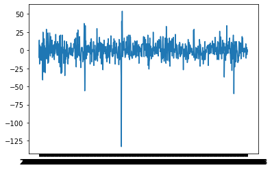

```python
series_diff = series.diff().dropna()
plt.plot(series_diff)
```

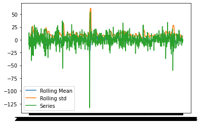

```python
plt.plot(series_diff.rolling(7).mean(),label="Rolling Mean")
plt.plot(series_diff.rolling(7).std(),label="Rolling std")
plt.plot(series_diff,label="Series")
plt.legend()
```

Again calculate the adfuller function

```python
adf = st.adfuller(x=series_diff, regression="ct", maxlag=12)
print("adf:", adf[0], "adf_pvalue:", adf[1])
```

```
adf: -20.565760159335618 adf_pvalue: 0.0
```

The result is now $0$, indicating stationarity

## ARCH

Autoregressive Conditional Heteroskedasticity. Describes the variance $\sigma^2$ of a random variable with the following equation:

$$ \sigma_t^2 = \gamma V_L + \sum_{i=1}^Q \alpha_i r_{t-i}^2$$

$r$ is the logarithmic return of the asset whose variance is being modelled. $VL$ is the long term variance. $\gamma$ and $\alpha$ are weights such that $\gamma + \sum \alpha =1$.

## GARCH

This adds a moving average to the equation.

$$ \sigma_t^2 = \gamma V_L + \sum_{i=1}^Q \alpha_i r_{t-i}^2 + \sum_{j=1}^P \beta_j \sigma_{t-j}^2 $$

So it has two parameters now, $p$ and $q$. We now have that $\gamma + \sum \alpha + \sum \beta =1$.

We start by installing pyflux

```python
!pip install pyflux-0.4.17-cp37-cp37m-win_amd64.whl
```

```
Processing c:\users\tbasi\onedrive\documentos\tareas\matrices aleatorias\mat\pyflux-0.4.17-cp37-cp37m-win_amd64.whl
pyflux is already installed with the same version as the provided wheel. Use --force-reinstall to force an installation of the wheel.
```

```python
import pyflux as pf
```

Apply the model to the returns of our series

```python
#create a model with p=q=1
model = pf.GARCH(np.array(series_diff),p=1,q=1)
x = model.fit()
x.summary()
```

```
GARCH(1,1)
======================================================= ==================================================
Dependent Variable: Series                              Method: MLE
Start Date: 1                                           Log Likelihood: -2830.7547
End Date: 734                                           AIC: 5669.5095
Number of observations: 734                             BIC: 5687.9035
==========================================================================================================
Latent Variable                          Estimate   Std Error  z        P>|z|    95% C.I.
======================================== ========== ========== ======== ======== =========================
Vol Constant                             53.4994
q(1)                                     0.3701
p(1)                                     0.3068
Returns Constant                         -0.0246    0.3696     -0.0667  0.9468   (-0.7491 | 0.6998)
==========================================================================================================
```

We can see the predicted values for the last 50 entries by this model and compare them with the real data

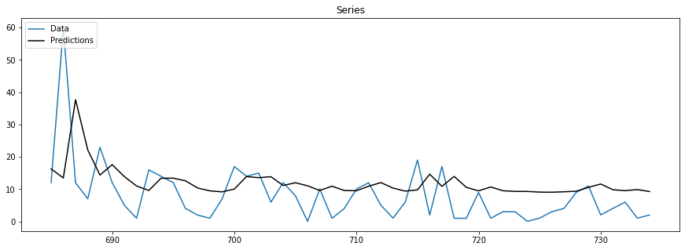

```python
model.plot_predict_is(h=50,figsize=(15,5))
```